# χ²検定の基礎と実践 by 戸田梨鈴

### 視覚化

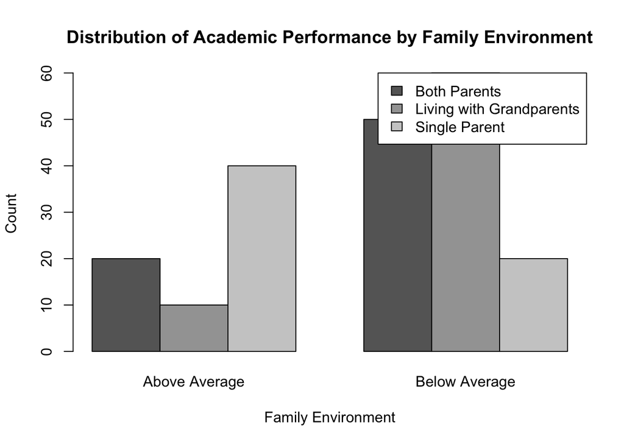

```r
# クロス集計表を棒グラフで表示
barplot(cross_table, beside = TRUE, col = gray.colors(3, start = 0.4, end = 0.8), legend.text = rownames(cross_table), args.legend = list(x = "topright"), xlab = "Family Environment", ylab = "Count", main = "Distribution of Academic Performance by Family Environment")
```

#### 結果の解釈

「R x 2」のχ²同質性検定とCramér’s Vの計算を用いて、「家庭環境は子供の学業成績に影響を及ぼす」という理論的仮説を統計的に検証しました。検証に使用した帰無仮説は、「3つの家庭環境の子供たちの間で、学業成績の分布は等しい」としました。それに対して対立仮説は「3つの家庭環境のうち、少なくとも一つの家庭環境で子供たちの学業成績の分布が他と異なる」と設定しました。

## 実践:「R x C」のχ²同質性検定

「R x C」形式のχ²同質性検定は、R個の群とC個のカテゴリーを比較する際に使用します。これはカテゴリカルデータの分布の一致性を検証する統計的手法で、複数の群とカテゴリが存在する場合のデータセットの分析に適用されます。

### 背景とデータの説明

子供の学習スタイルが年齢によってどの程度変化するかを検証します。具体的には、5歳、10歳、15歳の3つの年齢層の子供たちが視覚的、聴覚的、運動性という3つの学習スタイルにどの程度分布しているかを調査します。データは大阪府の子供を対象とした便宜的サンプリングにより収集します。

- 母集団: 日本全国の5歳、10歳、15歳の子供全体
- 標本: 大阪府の学校で調査を行い、各年齢層の学習スタイルの分布を代表すると考えられる子供たち

### 仮説の設定

- 理論的仮説：年齢は子どもたちの学習スタイルに影響を及ぼす可能性がある。
- 統計的仮説：
  - 帰無仮説 (H0): 5歳、10歳、15歳の子供たちの間で、学習スタイル（視覚的、聴覚的、運動性）の分布は同じである。
  - 対立仮説 (Ha): 少なくとも一つの年齢群の子供たちにおいて、学習スタイル（視覚的、聴覚的、運動性）の分布が他の年齢群と異なる。

### データの準備

以下のコードでは、年齢群と学習スタイルのカテゴリデータを生成し、それらを組み合わせたデータフレームを作成します。

- データの形式: 「年齢群」（5歳、10歳、15歳）と「学習スタイル」（視覚的、聴覚的、運動性）の2つのカテゴリカル変数を含む
- データ前処理: 欠損値や異常値が存在する場合は適切に処理します。欠損値は除去するか適切な値で補完し、異常値はデータの特性に基づいて適切に対応します。

```r
# 年齢群と学習スタイルを生成
age_group <- c(rep("5 years", 80), rep("10 years", 120), rep("15 years", 100))
learning_style <- c(rep("Visual", 40), rep("Auditory", 20), rep("Kinesthetic", 20),
                    rep("Visual", 20), rep("Auditory", 50), rep("Kinesthetic", 50),
                    rep("Visual", 20), rep("Auditory", 40), rep("Kinesthetic", 40))

# データフレームを作成
data_RxC <- data.frame(age_group, learning_style)
```

### 前提条件の検証

χ²同質性検定を行う前には、以下の前提条件が満たされていることを確認する必要があります。

- 観測データはカテゴリカルであること。
- 各標本（観測値）は独立していること。
- 全てのセル（クロス集計表の各要素）で期待度数が5以上であること。

まず、データをクロス集計表にまとめて視覚的に確認します。

```r
# クロス集計表を作成
cross_table <- table(data_RxC)

# クロス集計表を表示
print(cross_table)
```

```
##           learning_style
## age_group  Auditory Kinesthetic Visual
##   10 years       50          50     20
##   15 years       40          40     20
##   5 years        20          20     40
```

次に、全てのセルの期待度数が5以上であることを確認します。

```r
# 期待度数の確認
expected_values <- chisq.test(cross_table)$expected
all(expected_values >= 5)
```

```
## [1] TRUE
```

期待度数が5未満のセルが存在する場合、検定結果の解釈には注意が必要となります。次の代替的手法を検討することができます。

- **カテゴリの再分類**: 期待度数が5未満のカテゴリを組み合わせて、新たなカテゴリを作成し、それにより期待度数5未満のセルの数を減らす。
- **モンテカルロ法を使用したχ²検定**: サンプリング分布が理論的にわかっていない場合や、理論的な分布からの乖離が大きい場合に適用されます。
- **尤度比検定**: χ²検定と比較してより一般的な状況に適用でき、期待度数が低いセルがあっても使用することができます。

これらの手法は、研究の背景や目的、および使用可能なデータに応じて選択する必要があります。